# 05-The description of networks

### Modularity

The modularity of a network is the trend for subsets of nodes to interact more frequently among them than with other subsets of nodes (9). We resort to the package `bipartite` to estimate modularity (10), as it now implements a fast algorithm for its estimation (11).

The `computeModules` function in the package `bipartite` gives the modularity estimated value and the `plotModuleWeb` function plots the modular structure of the assemblage.

```r
# Modularity

data(Safariland)
        (res <- computeModules(Safariland))
```

```
## An object of class "moduleWeb"
## Slot "originalWeb":
##                          Policana albopilosa Bombus dahlbomii
## Aristotelia chilensis                    673                0
## Alstroemeria aurea                         0              154
## Schinus patagonicus                        0                0
##                          Ruizantheda mutabilis Trichophthalma amoena
## Aristotelia chilensis                      110                     0
## Alstroemeria aurea                           0                     0
## Schinus patagonicus                          0                     0
##                          Syrphus octomaculatus Manuelia gayi
## Aristotelia chilensis                        0             0
## Alstroemeria aurea                           5             7
## Schinus patagonicus                          0             0
##                          Allograpta.Toxomerus Trichophthalma jaffueli Phthiria
## Aristotelia chilensis                       0                       0        0
## Alstroemeria aurea                          1                       3        8
## Schinus patagonicus                         0                       0        0
##                          Platycheirus1 Sapromyza.Minettia Formicidae3
## Aristotelia chilensis                4                  0           0
## Alstroemeria aurea                   1                  1           0
## Schinus patagonicus                  0                  0           0
##                          Nitidulidae Staphilinidae Ichneumonidae4 Braconidae3
## Aristotelia chilensis              0             0              1           0
## Alstroemeria aurea                 0             4              0           0
## Schinus patagonicus                0             0             15           0
##                          Chalepogenus caeruleus Vespula germanica Torymidae2
## Aristotelia chilensis                         0                 0          0
## Alstroemeria aurea                            0                 4          0
## Schinus patagonicus                           0                 0          0
##                          Phthiria1 Svastrides melanura Sphecidae Thomisidae
## Aristotelia chilensis            0                   0         0          0
## Alstroemeria aurea               1                   6         1          1
## Schinus patagonicus              0                   0         0          0
##                          Corynura prothysteres Ichneumonidae2
## Aristotelia chilensis                        1              0
## Alstroemeria aurea                           3              4
## Schinus patagonicus                          0              0
##                          Ruizantheda proxima Braconidae2
## Aristotelia chilensis                      0           1
```

[output cut: 53 more lines]

```
##
## Slot "modules":
##      [,1] [,2] [,3] [,4] [,5] [,6] [,7] [,8] [,9] [,10] [,11] [,12] [,13] [,14]
## [1,]    0    1    1    2    3    4    5    6    7     8     9    10    11    12
## [2,]    1    0    1    0    0    0    0    0    0     0     0    10     0    12
##      [,15] [,16] [,17] [,18] [,19] [,20] [,21] [,22] [,23] [,24] [,25] [,26]
## [1,]    13    14    15    16    17    18    19    20    21    22    23    24
## [2,]     0     0     0     0     0     0    19     0     0     0     0     0
##      [,27] [,28] [,29] [,30] [,31] [,32] [,33] [,34] [,35] [,36] [,37] [,38]
## [1,]    25    26    27    28    29    30    31    32    33    34    35    36
## [2,]     0     0     0     0     0     0     0     0     0     0     0    36
##  [ reached getOption("max.print") -- omitted 4 rows ]
##
## Slot "likelihood":
## [1] 0.42974
```

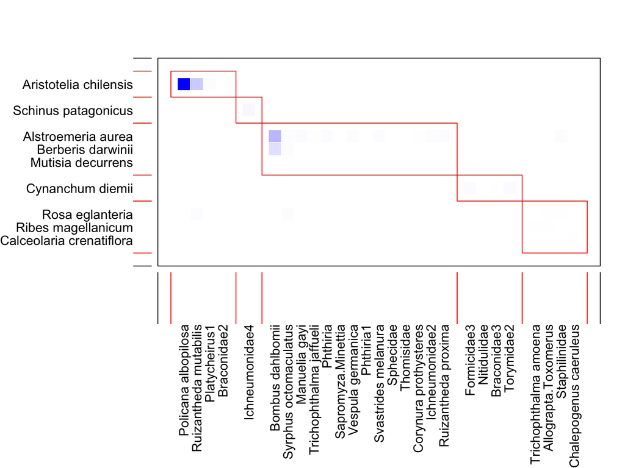

```r
        plotModuleWeb(res)
```

To proceed with analyses of multiple datasets it is convenient to have a function, where we can also extract the roles of the different species:

```
##
## Depth: 0
##
## Nr of module: 1
##
## Rownames:
##
##  Aristotelia chilensis
##  Alstroemeria aurea
##  Schinus patagonicus
##  Berberis darwinii
##  Rosa eglanteria
##  Cynanchum diemii
##  Ribes magellanicum
##  Mutisia decurrens
##  Calceolaria crenatiflora
##
## Colnames:
##
##  Policana albopilosa
##  Bombus dahlbomii
##  Ruizantheda mutabilis
##  Trichophthalma amoena
##  Syrphus octomaculatus
##  Manuelia gayi
##  Allograpta.Toxomerus
##  Trichophthalma jaffueli
##  Phthiria
##  Platycheirus1
##  Sapromyza.Minettia
##  Formicidae3
##  Nitidulidae
##  Staphilinidae
##  Ichneumonidae4
##  Braconidae3
##  Chalepogenus caeruleus
##  Vespula germanica
##  Torymidae2
##  Phthiria1
##  Svastrides melanura
```

[output cut: 95 more lines]

```
##
##  Aristotelia chilensis
##
## Colnames:
##
##  Policana albopilosa
##  Ruizantheda mutabilis
##  Platycheirus1
##  Braconidae2
##
## __________________________
##
## __________________________
##
## 0.42974
```

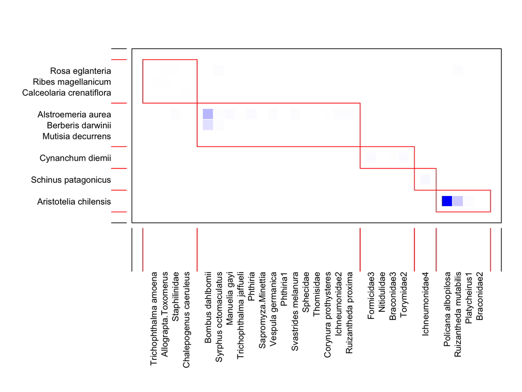

```r
modularity <- function (mat) {
    require(bipartite)
    (res <- computeModules(mat)) # takes several minutes!
    printoutModuleInformation(res)
    cat(res@likelihood)
    plotModuleWeb(res,labsize=0.8)
}

modularity(Safariland)
```

To get a significance test for modularity we need to generate null models of the matrix links, reshuffle them multiple times and then compare their distribution (randomized values) with our empirical estimate. This is quite computer intensive, especially for large matrices.

```r
# Testing modularity significance (@30 min for 100 null replicates)
TIME <- Sys.time()
mat <- Safariland                   # Assign the observed matrix
res <- computeModules(mat)          # Modularity for observed matrix
nulls <- nullmodel(mat, N= 99, method= 3)
modules.nulls <- sapply(nulls, computeModules)
like.nulls <- sapply(modules.nulls, function(x) x@likelihood)
z <- (res@likelihood - mean(like.nulls))/sd(like.nulls)
p <- 2*pnorm(-abs(z))
cat("P-value= ", p," ")          # P-value
```

```
## P-value=  3.8063e-65
```

```r
Sys.time() - TIME
```

```
## Time difference of 6.0501 secs
```

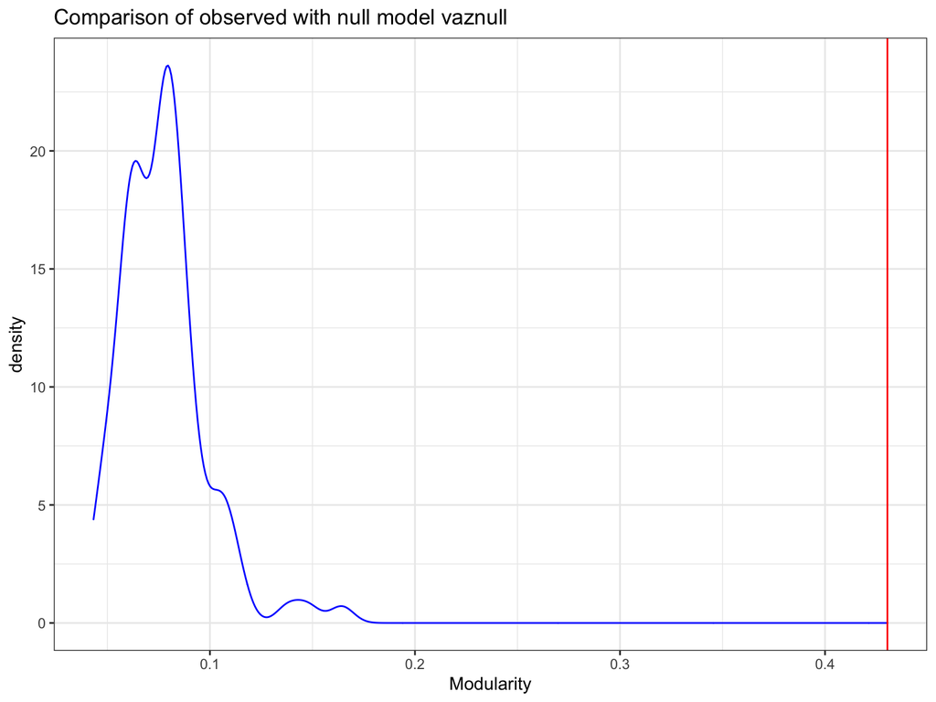

```r
#
# Plot
p <- ggplot(data= as.data.frame(like.nulls)) + theme_bw() +
            geom_density(aes(x=like.nulls, y= ..density..), color= 'blue')
p + geom_vline(xintercept= res@likelihood, color= "red") +
    labs(title= "Comparison of observed with null model vaznull",
         x = "Modularity")
```

## References

1.

Vazquez DP, Chacoff NP, Cagnolo L. 2009. Evaluating multiple determinants of the structure of plant-animal mutualistic networks. *Ecology*. 90:2039–46

2.

Jordano P. 1987. Patterns of mutualistic interactions in pollination and seed dispersal: Connectance, dependence asymmetries, and coevolution. *American Naturalist*. 129:657–77

3.

Dunne JA, Williams RJ, Martínez ND. 2002. Food-web structure and network theory: The role of connectance and size. *Proceedings National Academy of Sciences USA*. 99:12917–22

4.

Gotelli NJ, Graves GR. 1996. Null models in ecology

5.

Opsahl T. 2013. Triadic closure in two-mode networks: Redefining the global and local clustering coefficients. *Social Networks*. 35:159–67

6.

Dormann CF, Gruber B, Fruend J. 2008. Introducing the bipartite package: Analysing ecological networks. *R News*. 8(2):8–11

7.

Oksanen J, Blanchet FG, Friendly M, Kindt R, Legendre P, et al. 2018. *Vegan: Community ecology package*

8.

Almeida-Neto M, Ulrich W. 2011. A straightforward computational approach for measuring nestedness using quantitative matrices. *Environmental Modelling & Software*. 26:173–78

9.

Newman MEJ. 2006. Modularity and community structure in networks. *Proceedings National Academy of Sciences USA*. 103:8577

10.

Dormann CF, Strauss R. 2014. A method for detecting modules in quantitative bipartite networks. *Methods in Ecology and Evolution*. 5:90–98

11.

Beckett SJ. 2016. Improved community detection in weighted bipartite networks. *Royal Society Open Science*. 3:140536

12.

Ulrich W, Almeida-Neto M, Gotelli NJ. 2009. A consumer’s guide to nestedness analysis. *Oikos*. 118:3–17

13.

Fortuna MA, Stouffer DB, Olesen JM, Jordano P, Mouillot D, et al. 2010. Nestedness versus modularity in ecological networks: Two sides of the same coin? *J Anim Ecol*, pp. 1–7

Licensing Creative Commons License

Licensed under a Creative Commons Attribution-ShareAlike 4.0 International License.  
2018 - Pedro Jordano